# Práctica 3

```python
import Clasificador
import EstrategiaParticionado
from Datos import Datos
import pandas as pd
import matplotlib.pyplot as plt
```

## Apartado 1

Breve descripción de algunos detalles de la implementación. Solo es necesario especificar los siguientes aspectos:

### a) Generación de la población inicial con especial indicación del número de reglas por individuo consideradas

Hemos implementado una función dentro de la clase 'ClasificadorAlgoritmoGenentico' llamada 'generar_poblacion_inicial'. Esta función devuelve una población de individuos inicial en función a los parámetros con los que se instancia el clasificador. La función únicamente recibe el diccionario de los datos para saber la estructura de los individuos. Los parámetros condicionantes de la población son:

- El tamaño de la población.
- El número máximo de reglas de cada individuo (cada individuo tendrá un número de reglas aleatorio entre 1 y el máximo de reglas definido por este parámetro).

Generaremos tantos individuos como el tamaño de la población nos dicte, y los guardaremos en una lista llamada 'poblacion_inicial', que será lo que devuelva la función 'generar_poblacion_inicial'.

Los individuos son una lista de reglas (como ya hemos dicho antes, el número de reglas es aleatorio entre 1 y el parámetro establecido). Las reglas son una lista de atributos más una clase como elemento final de la lista (la clase se representa con un bit, 1 ó 0). Los atributos son una lista de valores (bits) de longitud igual al número de posibilidades dentro de cada atributo. Es decir, si un atributo tiene 3 posibilidades distintas, la lista 'atributo' (correspondiente a ese atributo) dentro de la regla tendrá 3 bits. Tanto los bits de los valores dentro de los atributos como el bit de la clase son generados aleatoriamente.

### b) Mecanismo de cruce implementado

El mecanismo de cruce que hemos implementado es el siguiente:

Se trata de un mecanismo de cruce total. Vamos recorriendo el número de individuos de 2 en 2, y según una probabilidad aleatoria condicionada por el parámetro del clasificador 'prob_cruce', los pares de individuos podrán cruzarse o no, generando en el primero de los casos 2 hijos que les sustituirán.

El cruce funciona de la siguiente forma:

- Elegimos aleatoriamente uno de los dos padres, y obtenemos el número máximo de reglas de éste (por ejemplo, 5 reglas). Entonces el hijo tendrá un número de reglas aleatorio entre 1 y el número de reglas máximo del padre seleccionado (p.e. un número aleatorio entre 1 y 5 -> 3).
- Para cada regla del hijo, eligiremos una regla aleatoria de cada padre (p.e. el primer padre tiene 5 reglas y elegimos su regla 3, el segundo padre solo tiene una regla asi que elegimos esta regla).
- Ahora eligiremos aleatoriamente cada bit de una de las reglas seleccionadas de los padres, incluyendo el bit de la clase. Es por esto que consideramos que el cruce es total, puesto que en vez de realizarse un cruce parcial en algún punto del cromosoma de bits, nosotros aplicamos un cruce aleatorio por cada bit.

Este proceso lo repetimos de forma completa una segunda vez para un segundo hijo, y posteriormente sustituimos los dos padres por los dos hijos.

### c) Mecanismo de mutación implementado

El mecanismo de cruce que hemos implementado es secuencial al de cruce (es decir, se aplica a la población resultante de la opearción de cruce) es el siguiente:

Recorremos cada individuo, y según una probabilidad aleatoria condicionada por el parámetro del clasificador 'prob_mutacion', los individuos podrán mutar o no.

La mutación funciona de la siguiente forma:

- Elegimos una regla aleatoria del individuo
- Elegimos aleatoriamente un bit de entre todos los bits del cromosoma (incluyendo el último bit de la clase) y cambiamos su valor (realizamos un bitflip, si vale 0 lo cambiamos a 1 y viceversa).

### d) Mecanismo de clasificación implementado

El mecanismo de que utlizamos en esta práctica para clasificar los datos es el siguiente:

Después de entrenar nuestra población durante una serie de generaciones (el entrenamiento se detiene cuando llegamos al número de épocas establecidas por el párametro 'num_epocas' o cuando se llega al número de generaciones sin mejorar establecido por el parámetro 'no_mejora') obtenemos el individuo con mejor fitness de la población. Utilizamos entonces este individuo únicamente para clasificar los datos de test desde la funcion 'clasifica', la cual devuelve una lista de predicciones de clase como el resto de clasificadores.

## Apartado 2

### Conjunto de datos 'tic-tac-toe.data'

```python
# Elegimos el conjunto de datos
dataset = Datos('./DatasetEjemplo/tic-tac-toe.data')

# Definimos una serie de listas para guardar los resultados que compararemos más adelante
lista_resultados_tictactoe = []
lista_indices_tictactoe = []
lista_num_pop_tictactoe = []
lista_epocas_tictactoe = []
```

Con 100 individuos y 100 épocas:

```python
# Elegimos la estrategia de particionado
estrategia = EstrategiaParticionado.ValidacionSimple(porcentaje_particion=50)

# Elegimos el clasificador
clasificador = Clasificador.ClasificadorAlgoritmoGenetico(tam_poblacion=100, num_epocas=100,
                                                          num_reglas_individuo=5,
                                                          prob_cruce=85, prob_mutacion=10,
                                                          prob_elitismo=5,no_mejora=100)
# Calculamos el error y la desviación tipica
error_media, error_std = clasificador.validacion(estrategia, dataset, clasificador)

lista_resultados_tictactoe.append(error_media)
lista_indices_tictactoe.append(1)
lista_num_pop_tictactoe.append(100)
lista_epocas_tictactoe.append(100)

print("Error:")
print(error_media)

clasificador.mejor_individuo()

tic_tac_toe_mejores_fitness = clasificador.mejores_fitness
tic_tac_toe_medios_fitness = clasificador.medios_fitness
```

```
Error:
0.34237995824634654
[[1, 1, 1], [1, 1, 1], [1, 1, 1], [1, 1, 1], [1, 1, 1], [1, 1, 1], [1, 1, 1], [1, 1, 1], [1, 1, 1], 1]
[[1, 1, 1], [1, 1, 1], [1, 1, 1], [1, 1, 1], [1, 1, 1], [1, 1, 1], [1, 1, 1], [1, 1, 1], [1, 1, 1], 1]
```

Con 100 individuos y 300 épocas:

```python
# Elegimos la estrategia de particionado
estrategia = EstrategiaParticionado.ValidacionSimple(porcentaje_particion=50)

# Elegimos el clasificador
clasificador = Clasificador.ClasificadorAlgoritmoGenetico(tam_poblacion=100, num_epocas=300,
                                                          num_reglas_individuo=5,
                                                          prob_cruce=85, prob_mutacion=10,
                                                          prob_elitismo=5,no_mejora=300)
# Calculamos el error y la desviación tipica
error_media, error_std = clasificador.validacion(estrategia, dataset, clasificador)

lista_resultados_tictactoe.append(error_media)
lista_indices_tictactoe.append(2)
lista_num_pop_tictactoe.append(100)
lista_epocas_tictactoe.append(300)

print("Error:")
print(error_media)

clasificador.mejor_individuo()
```

```
Error:
0.3235908141962422
[[1, 1, 1], [1, 1, 1], [1, 1, 1], [1, 1, 1], [1, 1, 1], [1, 1, 1], [1, 1, 1], [1, 1, 1], [1, 1, 1], 1]
```

```
[[[1, 1, 1],
  [1, 1, 1],
  [1, 1, 1],
  [1, 1, 1],
  [1, 1, 1],
  [1, 1, 1],
  [1, 1, 1],
  [1, 1, 1],
  [1, 1, 1],
  1]]
```

Con 200 individuos y 100 épocas:

```python
# Elegimos la estrategia de particionado
estrategia = EstrategiaParticionado.ValidacionSimple(porcentaje_particion=50)

# Elegimos el clasificador
clasificador = Clasificador.ClasificadorAlgoritmoGenetico(tam_poblacion=200, num_epocas=100,
                                                          num_reglas_individuo=5,
                                                          prob_cruce=85, prob_mutacion=10,
                                                          prob_elitismo=5,no_mejora=100)
# Calculamos el error y la desviación tipica
error_media, error_std = clasificador.validacion(estrategia, dataset, clasificador)

lista_resultados_tictactoe.append(error_media)
lista_indices_tictactoe.append(3)
lista_num_pop_tictactoe.append(200)
lista_epocas_tictactoe.append(100)

print("Error:")
print(error_media)

clasificador.mejor_individuo()
```

```
Error:
0.35073068893528186
[[1, 1, 1], [1, 1, 1], [1, 1, 1], [1, 1, 1], [1, 1, 1], [1, 1, 1], [1, 1, 1], [1, 1, 1], [1, 1, 1], 1]
```

```
[[[1, 1, 1],
  [1, 1, 1],
  [1, 1, 1],
  [1, 1, 1],
  [1, 1, 1],
  [1, 1, 1],
  [1, 1, 1],
  [1, 1, 1],
  [1, 1, 1],
  1]]
```

Con 200 individuos y 300 épocas:

```python
# Elegimos la estrategia de particionado
estrategia = EstrategiaParticionado.ValidacionSimple(porcentaje_particion=50)

# Elegimos el clasificador
clasificador = Clasificador.ClasificadorAlgoritmoGenetico(tam_poblacion=200, num_epocas=300,
                                                          num_reglas_individuo=5,
                                                          prob_cruce=85, prob_mutacion=10,
                                                          prob_elitismo=5,no_mejora=300)
# Calculamos el error y la desviación tipica
error_media, error_std = clasificador.validacion(estrategia, dataset, clasificador)

lista_resultados_tictactoe.append(error_media)
lista_indices_tictactoe.append(4)
lista_num_pop_tictactoe.append(200)
lista_epocas_tictactoe.append(300)

print("Error:")
print(error_media)

clasificador.mejor_individuo()
```

```
Error:
0.35281837160751567
[[1, 1, 1], [1, 1, 1], [1, 1, 1], [1, 1, 1], [1, 1, 1], [1, 1, 1], [1, 1, 1], [1, 1, 1], [1, 1, 1], 1]
```

```
[[[1, 1, 1],
  [1, 1, 1],
  [1, 1, 1],
  [1, 1, 1],
  [1, 1, 1],
  [1, 1, 1],
  [1, 1, 1],
  [1, 1, 1],
  [1, 1, 1],
  1]]
```

```python
dataFrame = zip(lista_indices_tictactoe, lista_resultados_tictactoe, lista_num_pop_tictactoe, lista_epocas_tictactoe)
tabla1 = pd.DataFrame(dataFrame, columns=["Número", "Tasa error (%)", "Tamaño de la población", "Número de épocas"]).style.hide_index()
display(tabla1)
```

| Número | Tasa error (%) | Tamaño de la población | Número de épocas |
| --- | --- | --- | --- |
| 1 | 0.34238 | 100 | 100 |
| 2 | 0.323591 | 100 | 300 |
| 3 | 0.350731 | 200 | 100 |
| 4 | 0.352818 | 200 | 300 |

### Breve Análisis de los Resultados Anteriores

Podemos observar que la tasa de error suele ser similar en cualquiera de los 4 casos (en torno a un 33%-35% de error) .

Esto se debe a que el individuo que mejor clasifica suele construirse con pocas reglas (1 ó 2 aunque el máximo de reglas está definido a 5) y todos los valores de las reglas están a 1 (indicando que aceptan cualquier posibilidad) incluyendo la clase (lo cual indica que la gran mayoría de los datos en nuestro conjunto clasifican a 1). Por ello este tipo de individuos tienden a ser los mejores.

### Conjunto de datos 'ejemplo1.data'

```python
# Elegimos el conjunto de datos
dataset = Datos('./DatasetEjemplo/ejemplo1.data')

# Definimos una serie de listas para guardar los resultados que compararemos más adelante
lista_resultados_tictactoe = []
lista_indices_tictactoe = []
lista_num_pop_tictactoe = []
lista_epocas_tictactoe = []
```

Con 100 individuos y 100 épocas:

```python
# Elegimos la estrategia de particionado
estrategia = EstrategiaParticionado.ValidacionSimple(porcentaje_particion=50)

# Elegimos el clasificador
clasificador = Clasificador.ClasificadorAlgoritmoGenetico(tam_poblacion=100, num_epocas=100,
                                                          num_reglas_individuo=5,
                                                          prob_cruce=85, prob_mutacion=10,
                                                          prob_elitismo=5,no_mejora=100)
# Calculamos el error y la desviación tipica
error_media, error_std = clasificador.validacion(estrategia, dataset, clasificador)

lista_resultados_tictactoe.append(error_media)
lista_indices_tictactoe.append(1)
lista_num_pop_tictactoe.append(100)
lista_epocas_tictactoe.append(100)

print("Error:")
print(error_media)

clasificador.mejor_individuo()


ejemplo1_mejores_fitness = clasificador.mejores_fitness
ejemplo1_medios_fitness = clasificador.medios_fitness
```

```
Error:
0.0
[[1, 0], [0, 1], 0]
[[1, 1], [0, 0], 0]
[[1, 0], [1, 0], 1]
[[0, 1], [0, 1], 1]
[[0, 1], [1, 0], 0]
```

Con 100 individuos y 300 épocas:

```python
# Elegimos la estrategia de particionado
estrategia = EstrategiaParticionado.ValidacionSimple(porcentaje_particion=50)

# Elegimos el clasificador
clasificador = Clasificador.ClasificadorAlgoritmoGenetico(tam_poblacion=100, num_epocas=300,
                                                          num_reglas_individuo=5,
                                                          prob_cruce=85, prob_mutacion=10,
                                                          prob_elitismo=5,no_mejora=300)
# Calculamos el error y la desviación tipica
error_media, error_std = clasificador.validacion(estrategia, dataset, clasificador)

lista_resultados_tictactoe.append(error_media)
lista_indices_tictactoe.append(2)
lista_num_pop_tictactoe.append(100)
lista_epocas_tictactoe.append(300)

print("Error:")
print(error_media)

clasificador.mejor_individuo()
```

```
Error:
0.52
[[1, 1], [1, 0], 0]
[[1, 1], [0, 1], 1]
```

```
[[[1, 1], [1, 0], 0], [[1, 1], [0, 1], 1]]
```

Con 200 individuos y 100 épocas:

```python
# Elegimos la estrategia de particionado
estrategia = EstrategiaParticionado.ValidacionSimple(porcentaje_particion=50)

# Elegimos el clasificador
clasificador = Clasificador.ClasificadorAlgoritmoGenetico(tam_poblacion=200, num_epocas=100,
                                                          num_reglas_individuo=5,
                                                          prob_cruce=85, prob_mutacion=10,
                                                          prob_elitismo=5,no_mejora=100)
# Calculamos el error y la desviación tipica
error_media, error_std = clasificador.validacion(estrategia, dataset, clasificador)

lista_resultados_tictactoe.append(error_media)
lista_indices_tictactoe.append(3)
lista_num_pop_tictactoe.append(200)
lista_epocas_tictactoe.append(100)

print("Error:")
print(error_media)

clasificador.mejor_individuo()
```

```
Error:
0.325
[[1, 0], [0, 1], 0]
[[0, 1], [1, 0], 0]
[[1, 0], [1, 0], 1]
```

```
[[[1, 0], [0, 1], 0], [[0, 1], [1, 0], 0], [[1, 0], [1, 0], 1]]
```

Con 200 individuos y 300 épocas:

```python
# Elegimos la estrategia de particionado
estrategia = EstrategiaParticionado.ValidacionSimple(porcentaje_particion=50)

# Elegimos el clasificador
clasificador = Clasificador.ClasificadorAlgoritmoGenetico(tam_poblacion=200, num_epocas=300,
                                                          num_reglas_individuo=5,
                                                          prob_cruce=85, prob_mutacion=10,
                                                          prob_elitismo=5,no_mejora=300)
# Calculamos el error y la desviación tipica
error_media, error_std = clasificador.validacion(estrategia, dataset, clasificador)

lista_resultados_tictactoe.append(error_media)
lista_indices_tictactoe.append(4)
lista_num_pop_tictactoe.append(200)
lista_epocas_tictactoe.append(300)

print("Error:")
print(error_media)

clasificador.mejor_individuo()
```

```
Error:
0.555
[[1, 1], [1, 1], 0]
```

```
[[[1, 1], [1, 1], 0]]
```

```python
dataFrame = zip(lista_indices_tictactoe, lista_resultados_tictactoe, lista_num_pop_tictactoe, lista_epocas_tictactoe)
tabla1 = pd.DataFrame(dataFrame, columns=["Número", "Tasa error (%)", "Tamaño de la población", "Número de épocas"]).style.hide_index()
display(tabla1)
```

| Número | Tasa error (%) | Tamaño de la población | Número de épocas |
| --- | --- | --- | --- |
| 1 | 0 | 100 | 100 |
| 2 | 0.52 | 100 | 300 |
| 3 | 0.325 | 200 | 100 |
| 4 | 0.555 | 200 | 300 |

### Conjunto de datos 'ejemplo2.data'

```python
# Elegimos el conjunto de datos
dataset = Datos('./DatasetEjemplo/ejemplo2.data')

# Definimos una serie de listas para guardar los resultados que compararemos más adelante
lista_resultados_tictactoe = []
lista_indices_tictactoe = []
lista_num_pop_tictactoe = []
lista_epocas_tictactoe = []
```

Con 100 individuos y 100 épocas:

```python
# Elegimos la estrategia de particionado
estrategia = EstrategiaParticionado.ValidacionSimple(porcentaje_particion=50)

# Elegimos el clasificador
clasificador = Clasificador.ClasificadorAlgoritmoGenetico(tam_poblacion=100, num_epocas=100,
                                                          num_reglas_individuo=5,
                                                          prob_cruce=85, prob_mutacion=10,
                                                          prob_elitismo=5,no_mejora=100)
# Calculamos el error y la desviación tipica
error_media, error_std = clasificador.validacion(estrategia, dataset, clasificador)

lista_resultados_tictactoe.append(error_media)
lista_indices_tictactoe.append(1)
lista_num_pop_tictactoe.append(100)
lista_epocas_tictactoe.append(100)

print("Error:")
print(error_media)

clasificador.mejor_individuo()

ejemplo2_mejores_fitness = clasificador.mejores_fitness
ejemplo2_medios_fitness = clasificador.medios_fitness
```

```
Error:
0.0
[[0, 1], [1, 1], 1]
[[1, 0], [1, 1], 0]
```

Con 100 individuos y 300 épocas:

```python
# Elegimos la estrategia de particionado
estrategia = EstrategiaParticionado.ValidacionSimple(porcentaje_particion=50)

# Elegimos el clasificador
clasificador = Clasificador.ClasificadorAlgoritmoGenetico(tam_poblacion=100, num_epocas=300,
                                                          num_reglas_individuo=5,
                                                          prob_cruce=85, prob_mutacion=10,
                                                          prob_elitismo=5,no_mejora=300)
# Calculamos el error y la desviación tipica
error_media, error_std = clasificador.validacion(estrategia, dataset, clasificador)

lista_resultados_tictactoe.append(error_media)
lista_indices_tictactoe.append(2)
lista_num_pop_tictactoe.append(100)
lista_epocas_tictactoe.append(300)

print("Error:")
print(error_media)

clasificador.mejor_individuo()
```

```
Error:
0.0
[[0, 1], [1, 1], 1]
[[1, 0], [1, 1], 0]
```

```
[[[0, 1], [1, 1], 1], [[1, 0], [1, 1], 0]]
```

Con 200 individuos y 100 épocas:

```python
# Elegimos la estrategia de particionado
estrategia = EstrategiaParticionado.ValidacionSimple(porcentaje_particion=50)

# Elegimos el clasificador
clasificador = Clasificador.ClasificadorAlgoritmoGenetico(tam_poblacion=200, num_epocas=100,
                                                          num_reglas_individuo=5,
                                                          prob_cruce=85, prob_mutacion=10,
                                                          prob_elitismo=5,no_mejora=100)
# Calculamos el error y la desviación tipica
error_media, error_std = clasificador.validacion(estrategia, dataset, clasificador)

lista_resultados_tictactoe.append(error_media)
lista_indices_tictactoe.append(3)
lista_num_pop_tictactoe.append(200)
lista_epocas_tictactoe.append(100)

print("Error:")
print(error_media)

clasificador.mejor_individuo()
```

```
Error:
0.0
[[1, 1], [1, 1], 1]
[[1, 0], [1, 1], 0]
[[1, 0], [1, 1], 0]
```

```
[[[1, 1], [1, 1], 1], [[1, 0], [1, 1], 0], [[1, 0], [1, 1], 0]]
```

Con 200 individuos y 300 épocas:

```python
# Elegimos la estrategia de particionado
estrategia = EstrategiaParticionado.ValidacionSimple(porcentaje_particion=50)

# Elegimos el clasificador
clasificador = Clasificador.ClasificadorAlgoritmoGenetico(tam_poblacion=200, num_epocas=300,
                                                          num_reglas_individuo=5,
                                                          prob_cruce=85, prob_mutacion=10,
                                                          prob_elitismo=5,no_mejora=300)
# Calculamos el error y la desviación tipica
error_media, error_std = clasificador.validacion(estrategia, dataset, clasificador)

lista_resultados_tictactoe.append(error_media)
lista_indices_tictactoe.append(4)
lista_num_pop_tictactoe.append(200)
lista_epocas_tictactoe.append(300)

print("Error:")
print(error_media)

clasificador.mejor_individuo()
```

```
Error:
0.0
[[1, 0], [1, 1], 0]
[[0, 1], [1, 1], 1]
```

```
[[[1, 0], [1, 1], 0], [[0, 1], [1, 1], 1]]
```

```python
dataFrame = zip(lista_indices_tictactoe, lista_resultados_tictactoe, lista_num_pop_tictactoe, lista_epocas_tictactoe)
tabla1 = pd.DataFrame(dataFrame, columns=["Número", "Tasa error (%)", "Tamaño de la población", "Número de épocas"]).style.hide_index()
display(tabla1)
```

| Número | Tasa error (%) | Tamaño de la población | Número de épocas |
| --- | --- | --- | --- |
| 1 | 0 | 100 | 100 |
| 2 | 0 | 100 | 300 |
| 3 | 0 | 200 | 100 |
| 4 | 0 | 200 | 300 |

### Breve Análisis de los Resultados Anteriores

Podemos observar que encontramos una solución completa repetidas veces con un individuo.

Este individuo es el:

[[1, 0], [1, 1], 0]

[[0, 1], [1, 1], 1]

o el mismo individuo con sus reglas invertidas:

[[0, 1], [1, 1], 1]

[[1, 0], [1, 1], 0]

Este individuo consigue clasificar correctamente todos los resultados (al menos en el número de ejecuciones que hemos realizado), lo cual indica que es una solución al problema.

### Comentario:

Hemos utilizado la estrategia de particionado 'Validación Simple' en esta práctica, ya que no afecta a la ejecución el tipo de particionado según nuestras ejecuciones, y puesto que la práctica tarda en ejecutarse, hemos elegido la estrategia de menor coste computacional.

## Apartado 3

Aunque hemos realizado un análisis de los resultados para cada conjunto, vamos a sintetizar toda esa información en este apartado:

El tamaño de la población es un parámetro que no ha implicado mucha diferencia, hemos podido notar que aún aumentando el tamaño, el tiempo de ejecución del clasificador no ha variado mucho, lo cual nos da a entender que simplemente con un número mayor de individuos tiende a encontrar un individuo mejor más rápido, pero debido al número de generaciones que hay, al final siempre se encuentran individuos similares.

Respecto a la tasa de mutación y de cruce, hemos observado que en poblaciones grandes y un número acotado de generaciones tiene un impacto mayor que con un número alto de generaciones. De todas formas, los resultados finales están condicionados sobre todo por la posibilidad del elitismo, dejando al cruce y la mutación en segundo plano.

## Apartado 4

### Conjunto de datos 'tic-tac-toe.data'

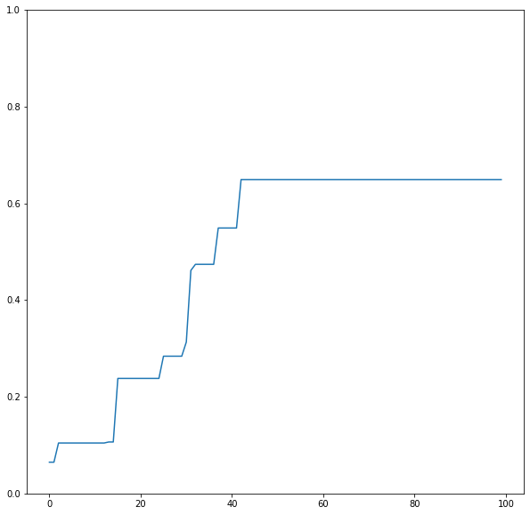

```python
fig = plt.figure(figsize = (10,10))
plt.ylim(0.0, 1.0)
plt.plot(range(0, 100), tic_tac_toe_mejores_fitness)
```

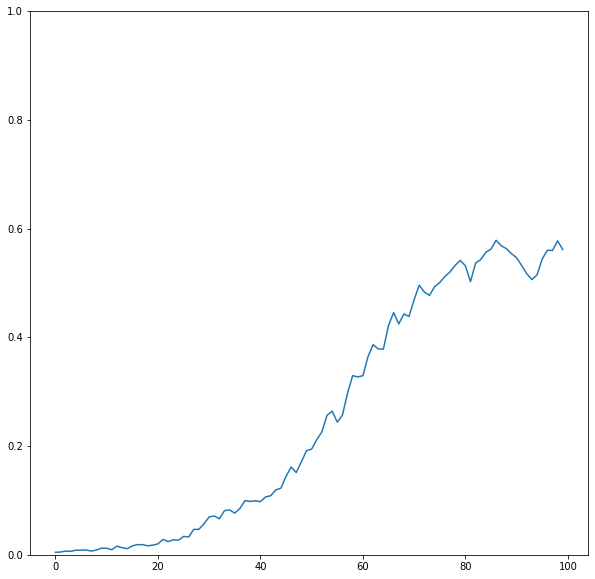

```python
fig = plt.figure(figsize = (10,10))
plt.ylim(0.0, 1.0)
plt.plot(range(0, 100), tic_tac_toe_medios_fitness)
```

Podemos observar en el conjunto de datos de 'tic-tac-toe.data' que tanto el mejor individuo como la población en general van mejorando hasta cierto punto donde se estancan. Esto ocurre debido a nuestra implementación del cruce total (cruce bit a bit) que genera un individuo con todos o casi todos los valores a 1, y de ahí no mejora. Aun así obtenemos unos resultados aceptables.

### Conjunto de datos 'ejemplo1.data'

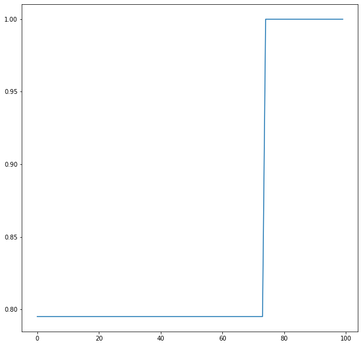

```python
fig = plt.figure(figsize = (10,10))
#plt.ylim(0.0, 1.0)
plt.plot(range(0, 100), ejemplo1_mejores_fitness)
```

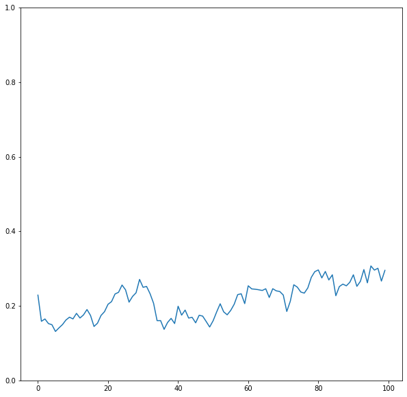

```python
fig = plt.figure(figsize = (10,10))
plt.ylim(0.0, 1.0)
plt.plot(range(0, 100), ejemplo1_medios_fitness)
```

Aquí vemos que uno de los individuos alcanza la solución correcta (coloquialmente podríamos decir, que "da en el blanco") obteniendo el conjunto de reglas que da solución al conjunto de datos. Se puede observar una ligera mejoría en la media de la población con el paso del tiempo.

### Conjunto de datos 'ejemplo2.data'

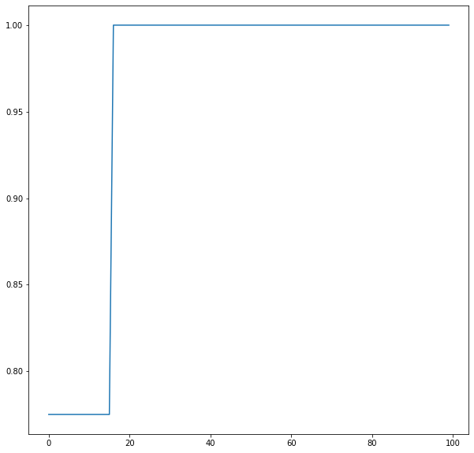

```python
fig = plt.figure(figsize = (10,10))
# plt.ylim(0.0, 1.0)
plt.plot(range(0, 100), ejemplo2_mejores_fitness)
```

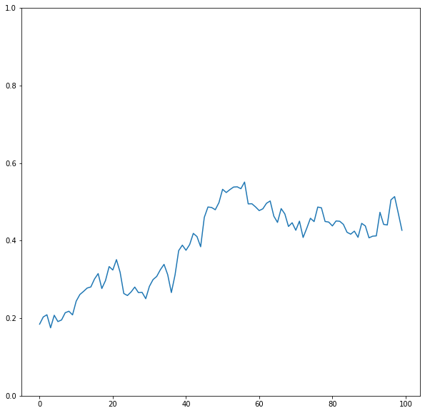

```python
fig = plt.figure(figsize = (10,10))
plt.ylim(0.0, 1.0)
plt.plot(range(0, 100), ejemplo2_medios_fitness)
```

En estas últimas graficas observamos que un individuo alcanza la solución rapidamente (alrededor de la generación 18). El resto de individuos mejora su fitness hasta cierto punto donde se estanca.